# Bioconductor Overview: edX 525.5x Part I

Vincent J. Carey

17 July 2017

#### Package

edx2017 0.0.0

# 1 The R language and its packages and repositories

This course assumes a good working knowledge of the R language. The Rstudio environment is recommended. If you want to work through a tutorial before proceeding, [Try R](http://tryr.codeschool.com/) is very comprehensive.

## 1.1 Why R?

Bioconductor is based on R. Three key reasons for thisare:

- R is used by many statisticians and biostatisticians to create algorithms that advance our ability to understand complex experimental data.
- R is highly interoperable, and fosters reuse of software components written in other languages.
- R is portable to the key operating systems running on commodity computing equipment (Linux, MacOSX, Windows) and can be used immediately by beginners with access to any of these platforms.

In summary, R’s ease-of-use and central role in statistics and “data science” make it a natural choice for a tool-set for use by biologists and statisticians confronting genome-scale experimental data. Since the Bioconductor project’s inception in 2001, it has kept pace with growing volumes and complexity of data emerging in genome-scale biology.

## 1.2 Functional object-oriented programming

R combines functional and object-oriented programming paradigms.

[Chambers 2014](https://projecteuclid.org/euclid.ss/1408368569)

- In functional programming, notation and program activity mimic the concept of function in mathematics. For example

  ```
  square = function(x) x^2
  ```

  is valid R code that defines the symbol `square` as a function that computes the second power of its input. The body of the function is the program code `x^2`, in which `x` is a “free variable”. Once `square` has been defined in this way, `square(3)` has value `9`. We say the `square` function has been evaluated on argument `3`. **In R, all computations proceed by evaluation of functions.**
- In object-oriented programming, a strong focus is placed upon formalizing data structure, and defining methods that take advantage of guarantees established through the formalism. This approach is quite natural but did not get well-established in practical computer programming until the 1990s. As an advanced example with Bioconductor, we will consider an approach to defining an “object” representing on the genome of *Homo sapiens*:

```r
library(Homo.sapiens)
class(Homo.sapiens)
```

```
## [1] "OrganismDb"
## attr(,"package")
## [1] "OrganismDbi"
```

```r
methods(class=class(Homo.sapiens))
```

```
##  [1] asBED                 asGFF                 cds
##  [4] cdsBy                 coerce<-              columns
##  [7] dbconn                dbfile                disjointExons
## [10] distance              exons                 exonsBy
## [13] extractUpstreamSeqs   fiveUTRsByTranscript  genes
## [16] getTxDbIfAvailable    intronsByTranscript   isActiveSeq
## [19] isActiveSeq<-         keys                  keytypes
## [22] mapIds                mapToTranscripts      metadata
## [25] microRNAs             promoters             resources
## [28] select                selectByRanges        selectRangesById
## [31] seqinfo               show                  taxonomyId
## [34] threeUTRsByTranscript transcripts           transcriptsBy
## [37] tRNAs                 TxDb                  TxDb<-
## see '?methods' for accessing help and source code
```

We say that `Homo.sapiens` is an **instance** of the `OrganismDb` **class**. Every instance of this class must respond to the methods listed above. Of special note at this juncture are the methods `genes`, `exons`, `transcripts` which will yield information about fundamental components of genomes used to devise and interpret molecular assays. These methods will succeed for human and for other model organisms such as *Mus musculus*, *S. cerevisiae*, *C. elegans*, and others for which the Bioconductor project and its contributors have defined `OrganismDb` representations.

# 2 The central dogma of molecular biology restated

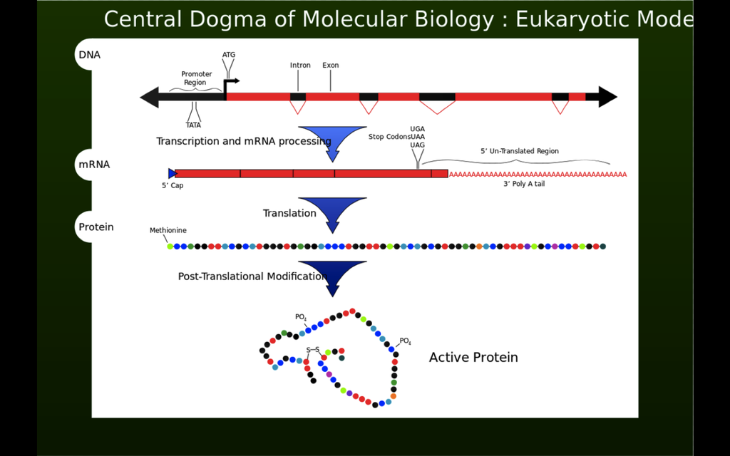

Figure 1: Wikipedia schematic  
Chromosomes are composed of coding and non-coding DNA sequence. Coding sequence includes exons and introns. Exons are spliced and transcribed to messenger RNA, which is then processed and translated to active protein.

# 3 A collection of genome-scale assays

## 3.1 The complete DNA sequence for an organism’s reference genome

## 3.2 SNPs: cataloging population-level variation in DNA sequence

## 3.3 mRNA abundance estimates: depicting transcriptional states

## 3.4 Epigenomics: how regulatory factors bind to DNA to control transcription and translation

## 3.5 Other crucial assay classes: Proteomics, metabolomics, microbiomics, whole-genome editing

## 3.6 Coda: the single cell revolution

# 4 Data structures for genome-scale assays

# 5 Exploring genome-scale assay data

# 6 Testing statistical hypotheses with genome-scale assays